# CPP 528 Lab 03

Team 2

4/5/2022

## Part 1: Create dataset for analysis

1990-2000 variables

Summary Statistics

| Variable | N | Mean | Std. Dev. | Min | Pctl. 25 | Pctl. 50 | Pctl. 75 | Max |
| --- | --- | --- | --- | --- | --- | --- | --- | --- |
| mhmval90 | 59722 | 112399.2 | 82536.6 | 0 | 58800 | 86500 | 141800 | 500001 |
| mhmval00 | 59722 | 144738 | 104762.5 | 0 | 81600 | 119900 | 173894 | 1000001 |
| hinc90 | 59722 | 34160.2 | 14733.7 | 4999 | 24355.2 | 32033 | 41519.9 | 150001 |
| hinc00 | 59722 | 47657.3 | 21410.8 | 2499 | 33000 | 43825 | 58036 | 200001 |
| hu90 | 59722 | 1382.4 | 703.2 | 0 | 916.2 | 1337 | 1803.5 | 11003 |
| own90 | 59722 | 787.8 | 480.9 | 0 | 421.9 | 743.5 | 1093 | 8180.1 |
| rent90 | 59722 | 476.1 | 435.8 | 0 | 168.1 | 357.7 | 662.5 | 8653 |
| empclf90 | 59722 | 1625.2 | 861.6 | 0 | 1015 | 1554.5 | 2157.4 | 11816 |
| clf90 | 59722 | 1731.8 | 900.3 | 0 | 1101 | 1664.4 | 2291 | 12497 |
| unemp90 | 59722 | 106.6 | 83.8 | 0 | 48.9 | 87.6 | 142.7 | 1165 |
| prof90 | 59722 | 451 | 362.3 | 0 | 191.8 | 358.9 | 615.7 | 6290 |
| dpov90 | 59722 | 3331.6 | 1635.3 | 0 | 2218.9 | 3250.1 | 4365.5 | 23619 |
| npov90 | 59722 | 406.4 | 461.4 | 0 | 111.7 | 248.5 | 526.5 | 5889.8 |
| ag25up90 | 59722 | 2186.6 | 1087.1 | 0 | 1444.4 | 2121 | 2865 | 18461 |
| hs90 | 59722 | 1140.8 | 692.1 | 0 | 626 | 1063.9 | 1559 | 12383.2 |
| col90 | 59722 | 482.6 | 469 | 0 | 162 | 335.3 | 652.1 | 8575 |
| pop90.x | 59722 | 3419 | 1671.1 | 0 | 2282.9 | 3325 | 4464.3 | 35721.3 |
| nhwht90 | 59722 | 2513.5 | 1619.4 | 0 | 1262.1 | 2424 | 3575 | 21560.7 |
| nhblk90 | 59722 | 426.4 | 889.9 | 0 | 17.8 | 76 | 331 | 12121 |
| hisp90 | 59722 | 347.3 | 742.9 | 0 | 26.8 | 75 | 279.6 | 13873.3 |
| asian90 | 59722 | 111 | 283.6 | 0 | 9.5 | 31 | 94.2 | 7899 |
| p.white | 59594 | 74.3 | 28.6 | 0 | 64.1 | 86.9 | 95.1 | 100 |
| p.black | 59594 | 12.2 | 22.7 | 0 | 0.7 | 2.6 | 10.5 | 100 |
| p.hisp | 59594 | 9.8 | 17.3 | 0 | 1 | 2.6 | 9.3 | 100 |
| p.asian | 59594 | 3 | 6.6 | 0 | 0.4 | 1.1 | 2.8 | 93.8 |
| p.hs | 59578 | 74 | 7.8 | 0 | 68.6 | 74 | 79.5 | 100 |
| p.col | 59578 | 21.7 | 15.3 | 0 | 10 | 17.5 | 29.9 | 100 |
| p.prof | 59552 | 26.7 | 12.3 | 0 | 17.4 | 24.5 | 34.1 | 100 |
| p.unemp | 59552 | 6.6 | 4.9 | 0 | 3.5 | 5.2 | 7.9 | 63.9 |
| pov.rate | 59552 | 12.3 | 12 | 0 | 4.3 | 8.2 | 15.9 | 100 |
| mhv.change | 59722 | -94 | 59505.9 | -644276.3 | -19538.7 | 2673.1 | 21556.4 | 1000001 |
| pct.change | 59577 | 0.1 | 0.4 | -1 | -0.1 | 0 | 0.2 | 29 |
| mhv.00 | 59722 | 144738 | 104762.5 | 0 | 81600 | 119900 | 173894 | 1000001 |
| mhv.90 | 59577 | 145184.2 | 106241.8 | 11432.6 | 76024.5 | 111588.4 | 182974.1 | 644276.3 |

### Exploration of median home value

Summary Statistics

| Variable | N | Mean | Std. Dev. | Min | Pctl. 25 | Pctl. 50 | Pctl. 75 | Max |
| --- | --- | --- | --- | --- | --- | --- | --- | --- |
| MedianHomeValue1990 | 59722 | 144832 | 106352.6 | 0 | 75766.7 | 111459.6 | 182716.4 | 644276.3 |
| MedianHomeValue2000 | 59722 | 144738 | 104762.5 | 0 | 81600 | 119900 | 173894 | 1000001 |
| Change.90.to.00 | 59722 | -94 | 59505.9 | -644276.3 | -19538.7 | 2673.1 | 21556.4 | 1000001 |

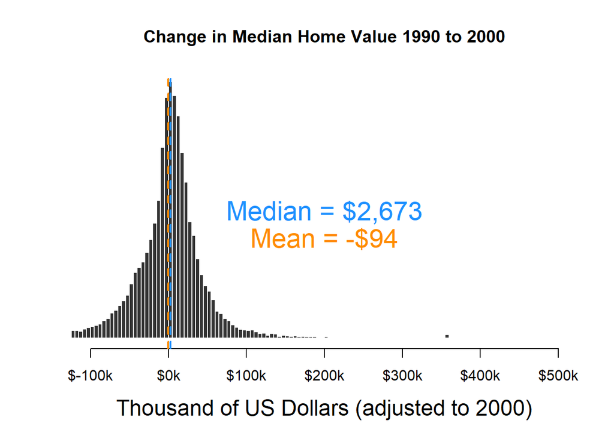

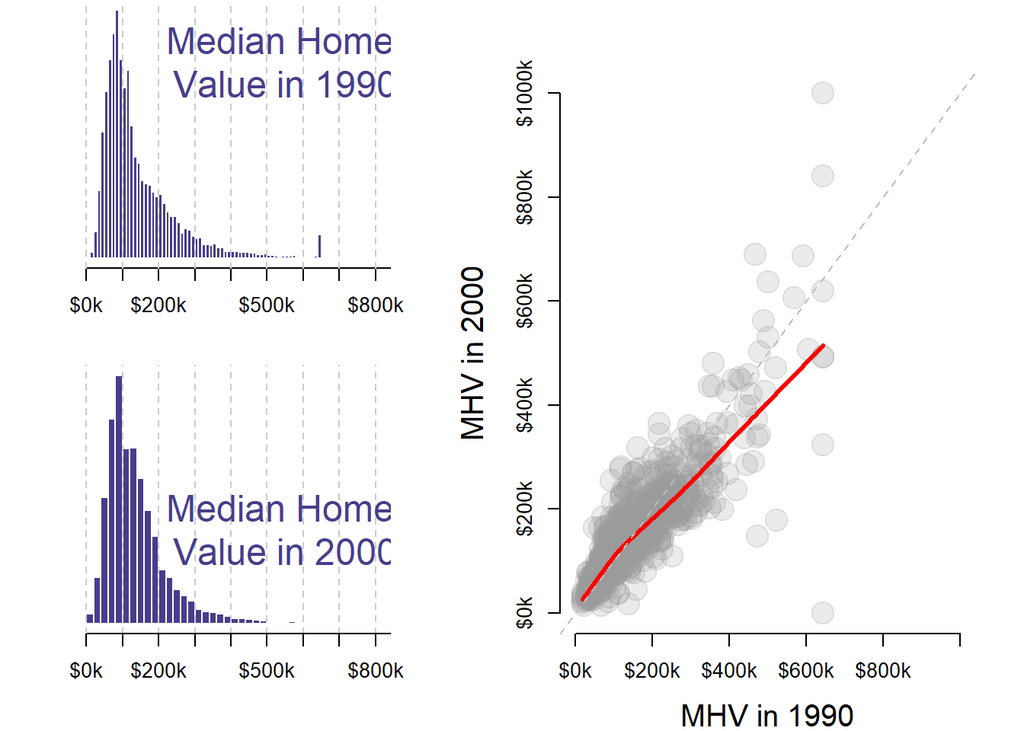

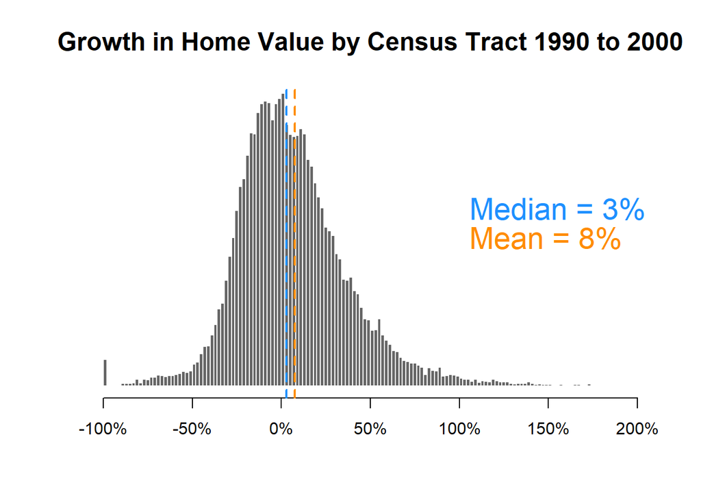

### Growth rates by metro area, areas with greatest growth

| cbsaname | ave.change.d | growth |
| --- | --- | --- |
| Corvallis, OR | $75,677 | 79.7 |
| Portland-Vancouver-Beaverton, OR-WA | $70,351 | 75.99 |
| Salt Lake City, UT | $63,611 | 73.15 |
| Boulder, CO | $97,867 | 72.67 |
| Provo-Orem, UT | $62,514 | 71.93 |
| Salem, OR | $50,438 | 65.21 |
| Eugene-Springfield, OR | $52,973 | 65.05 |
| Fort Collins-Loveland, CO | $59,194 | 60.12 |
| Longview, WA | $42,674 | 58.84 |
| Missoula, MT | $47,327 | 58.12 |
| Jackson, MI | $29,592 | 57.16 |
| Greeley, CO | $43,812 | 55.39 |
| Wenatchee, WA | $48,081 | 54.12 |
| Detroit-Livonia-Dearborn, MI | $30,657 | 53.02 |
| Yakima, WA | $32,136 | 52.99 |
| Ogden-Clearfield, UT | $44,400 | 52.13 |
| Denver-Aurora, CO | $54,759 | 51.55 |
| Monroe, MI | $44,396 | 50.97 |
| Bay City, MI | $27,934 | 50.63 |
| Logan, UT-ID | $37,446 | 50 |
| Eau Claire, WI | $29,110 | 46.51 |
| Madison, WI | $45,474 | 45.61 |
| Sioux Falls, SD | $32,998 | 44.55 |
| Grand Junction, CO | $36,277 | 44.34 |
| Mount Vernon-Anacortes, WA a | $43,935 | 44.04 |

## Part 02: Measuring gentrification

```r
summary( pct.change )
```

```
##     Min.  1st Qu.   Median     Mean  3rd Qu.     Max.     NA's
## -1.00000 -0.13890  0.02888  0.07583  0.23156 29.03826      145
```

Summary Statistics

| Variable | N | Mean | Std. Dev. | Min | Pctl. 25 | Pctl. 50 | Pctl. 75 | Max |
| --- | --- | --- | --- | --- | --- | --- | --- | --- |
| v00 | 995 | 144.1 | 104.5 | 17.7 | 76.2 | 110.9 | 184.4 | 644.3 |
| v10 | 1000 | 144.1 | 98.6 | 0 | 80.8 | 120.8 | 181.4 | 1000 |

### Operationalizing Gentrification

We selected the following factors as possible indicators of tracts eligible for gentrification:

### Number of tracts that met each of these criteria

```r
sum( lowhomeval.1990, na.rm = T )
```

```
## [1] 34602
```

```r
sum( vacant.1990, na.rm = T )
```

```
## [1] 17610
```

```r
sum( lowrent.1990, na.rm = T )
```

```
## [1] 1464
```

```r
sum( diverse.1990, na.rm = T )
```

```
## [1] 24415
```

```r
sum( unemployment.1990, na.rm = T )
```

```
## [1] 14501
```

```r
sum( lowed.1990, na.rm = T )
```

```
## [1] 14911
```

```r
sum( highpoverty.1990, na.rm = T )
```

```
## [1] 14801
```

### Number of tracts that met **all** of these criteria

```r
gent.candidate <- sum( lowhomeval.1990 & vacant.1990  & lowrent.1990 &
                         diverse.1990 & unemployment.1990 & lowed.1990 &
                         highpoverty.1990, na.rm = T )
gent.candidate
```

```
## [1] 418
```

Using all of the criteria listed, only 418 tracts were eligible for gentrification

### Number of tracts that met at least one property-related criterion, were racially/ethnically diverse, met at least one income-related criterion, and had low college education rates in 1990

```r
gent.candidate2 <- sum(( lowhomeval.1990 | vacant.1990 | lowrent.1990 ) &
                          diverse.1990 & (unemployment.1990 | highpoverty.1990 ) &
                          lowed.1990, na.rm = T )
gent.candidate2
```

```
## [1] 7315
```

By combining the three property criteria (so a tract can be selected if it has low home values and/or high vacancies and/or low rent), and combining the two income factors (unemployment and/or high poverty rate), the number of tracts eligible for gentrification increased to 7315.

```r
gentrified <- ( lowhomeval.1990 | vacant.1990 | lowrent.1990 ) &
                          diverse.1990 & (unemployment.1990 | highpoverty.1990 ) &
                          lowed.1990 & mhv.pct.increase & home.val.rise & loss.diversity
num.gentrified <- sum( gentrified, na.rm=T )
num.gentrified
```

```
## [1] 0
```

```r
gentrified.lowmhv <- ( lowhomeval.1990 ) & mhv.pct.increase & home.val.rise & loss.diversity
num.gentrified.lowmhv <- sum( gentrified.lowmhv, na.rm = T)
num.gentrified.lowmhv
```

```
## [1] 0
```

```r
gent.candidate2
```

```
## [1] 7315
```

```r
pct.gentrified <- num.gentrified / gent.candidate2
pct.gentrified
```

```
## [1] 0
```

Using this approach, no tracts became gentrified from 1990 to 2000.

```r
# small initial values are skewing percentages
#
# an average home value below $10k is really low -
# these must be mostly vacant lots?
mhv.90[ mhv.90 < 1000 ] <- NA
pct.change <- 100 * ( mhv.change / mhv.90 )
summary( pct.change )
```

```
##     Min.  1st Qu.   Median     Mean  3rd Qu.     Max.     NA's
## -100.000  -13.890    2.888    7.583   23.156 2903.825      145
```

## Part 03: Spatial Patterns

For this analysis we use the Milwaukee, Wisconsin metropolitan area, comprising the four metro counties: Milwaukee, Waukesha, Ozaukee, and Washington.

### Milwaukee metro area census tracts with population shown

[interactive chart not shown]

[figure not shown]

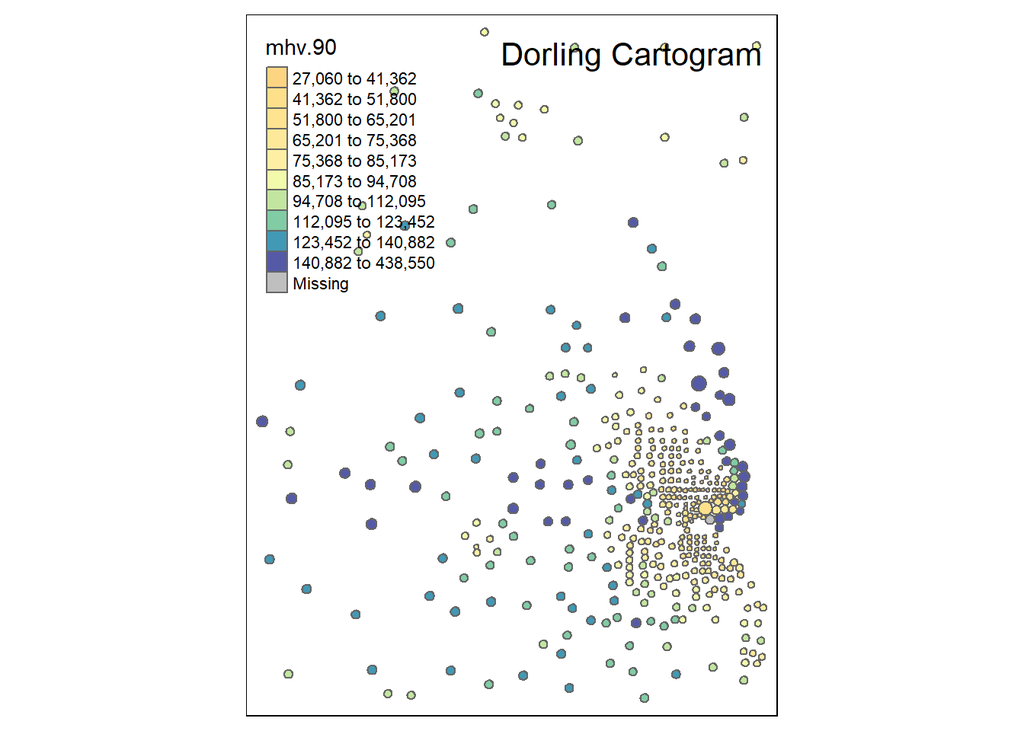

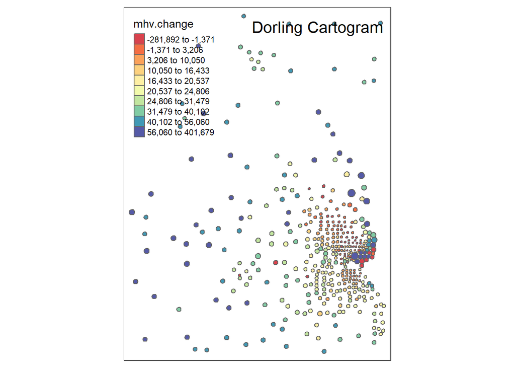

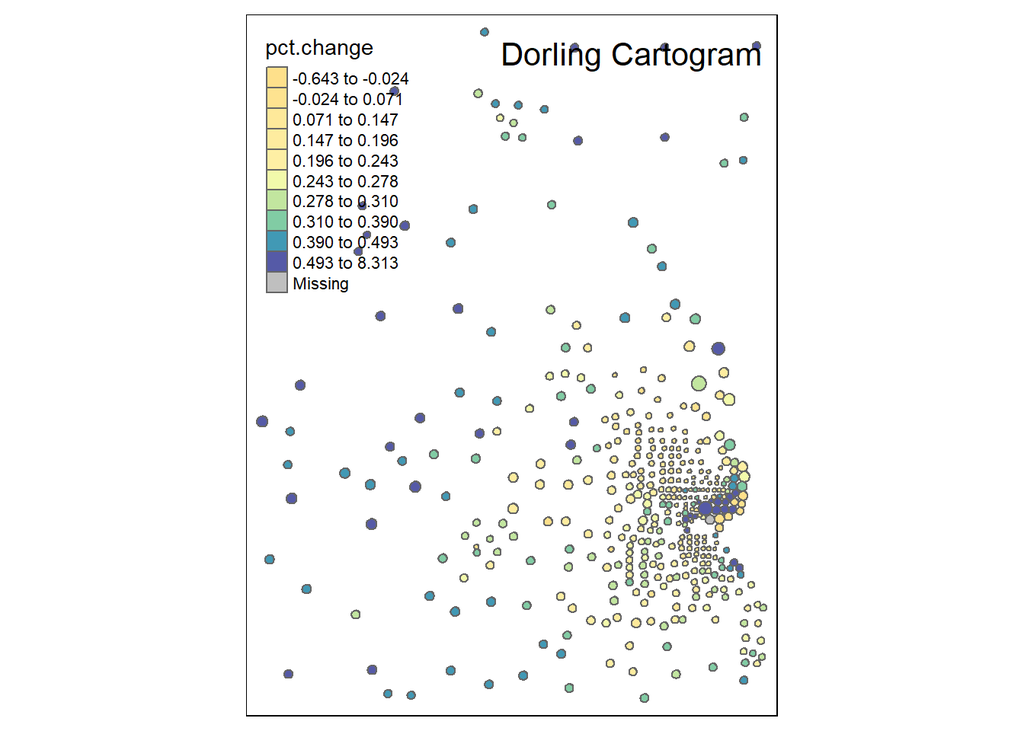

**Median Home Values** In 1990, high-value tracts were concentrated north of downtown along the lakefront (the far right edge of the map) and scattered through the northern and western suburbs. Low-value tracts are located in the central city, southern city and suburbs, and northwest areas of the city.

**Compare values in 2000 to changes in values from 1990-2000. Do the largest gains occur in tracts with above or below-average home prices in 2000?** The most striking areas with gains from 1990-2000 were lower-value but adjacent to high-value areas in 1990. There is a cluster with gains downtown and just west of the lakefront, while areas along the lake downtown had losses during this period.

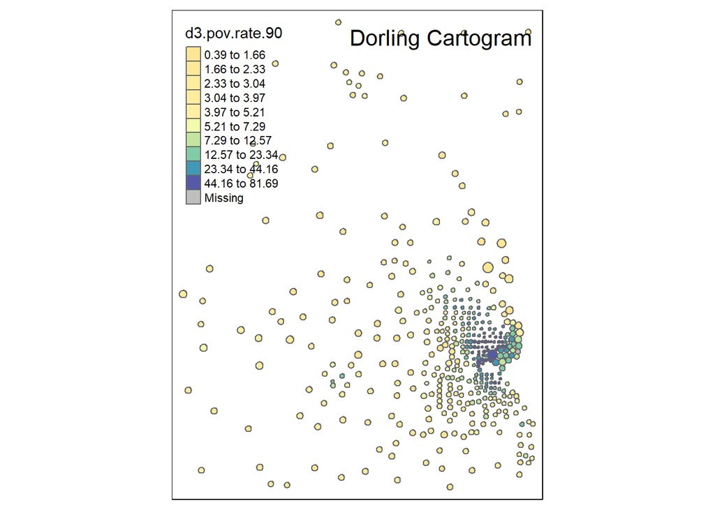

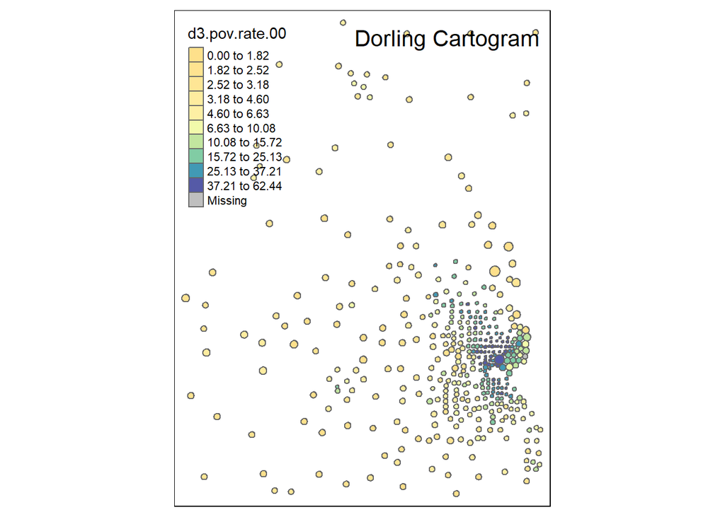

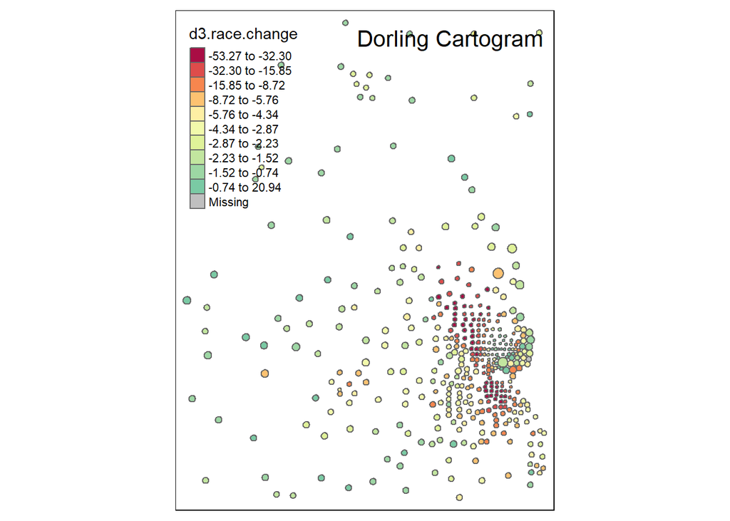

These maps along with the map above showing percent change in median home value change from 1990 to 2000 help show the areas where in 1990 there was very high poverty and between 1990 and 2000 property values rose at the same time that the racial mix of residents stayed fairly stable or became more white. It does appear that the area just west of the lakefront in the downtown area experienced gentrification during this time period.